# Navigation2D

# Navigation2D shows you how to get from one place to another

`Navigation2D` finds a path between two points in 2D space, moving around any obstacles or walls in its path.

It’s ideal for creating AI that considers its surroundings while hunting for a target. Some examples are enemies chasing the player or army units that avoid hazards as they move into position.

`Navigation2D` has some shortcomings that Godot 4.0 will fix, but it works as a quick and straightforward solution to 2D pathfinding in Godot 3.x.

In this guide, you will learn:

- How to set up a `Navigation2D`
- How to create simple pathfinding
- How to get chased by enemy AI
- How to avoid hazards and locked doors

Contents:

- Setting up a Navigation2D
- Navigation2D’s key features
  - Find target locations with get_closest_point()
  - Find paths with get_simple_path()
  - Switch between NavigationPolygonInstances with Enabled
- How to use a Navigation2D in practice
  - Making enemies chase the player
  - Grid-based navigation
  - Making areas inaccessible with doors
  - Reacting to moving hazards
- Your questions
  - When should I use AStar?
  - How can I see my Navigation shapes?
  - Can I create my NavigationPolygon in code?

## Setting up a Navigation2D

Every `Navigation2D` needs to have a child `NavigationPolygonInstance` before it can find paths. This child holds a `NavigationPolygon` resource, which defines the space available for points and paths.

To edit the space of a `NavigationPolygon`, you can add points using the toolbar on the viewport: *Create Points*, *Edit Points*, and *Erase Points*. These are the same tools as editing a `Polygon2D` or `CollisionPolygon2D`.

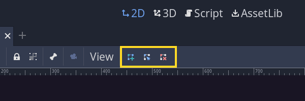

Once you add a polygon, you can hollow out areas inside the polygon by clicking *Add Point* again and building a new polygon inside the previous polygon.

## Navigation2D’s key features

### Find target locations with get_closest_point()

If you pass a position to this function, it returns the closest valid point on the *NavigationPolygon*. This function is essential if you have two navigation polygons and want a body to navigate from one to another, or to ensure your AI won’t go out of bounds.

### Find paths with get_simple_path()

This function is why *Navigation2D* is so useful. You pass in two points as parameters, where you want to navigate to and from in the `NavigationPolygonInstance`. The function finds the nearest points in the polygon and returns a `PoolVector2Array` path from the origin to the destination.

`get_simple_path()` has three parameters: a start position, an end position, and a boolean called *Optimize*. *Optimize* is an optional parameter that merges points if they are in a straight line, and it’s set to true by default.

`get_simple_path()` is far from perfect because it can return unoptimized paths. Godot 4.0 looks to fix these imperfections, but it gives decent results with little tweaking for most situations.

### Switch between NavigationPolygonInstances with Enabled

The `NavigationPolygonInstance` itself has a few key properties that help customize the area you want to navigate.

You can access and edit the `NavigationPolygon` using the *Navpoly* property.

Also, you can enable or disable an entire `NavigationPolygonInstance` with the *Enabled* property. A `Navigation2D` can use only one `NavigationPolygonInstance` at a time, so we can change the shape by enabling one polygon and disabling the others.

## How to use a Navigation2D in practice

Now let’s look at some concrete use cases for `Navigation2D`.

### Making enemies chase the player

Almost all games with enemies have some simple pathfinding behind their movement.

For example, *Hotline Miami* has enemies that rush you with baseball bats, while *Civilization V* has units moving from tile to tile. At its core, almost any game needs some simple form of pathfinding to avoid characters crashing into walls.

`Navigation2D` is the best node for getting this behavior in Godot. To demonstrate this, we use an enemy ship that chases the player.

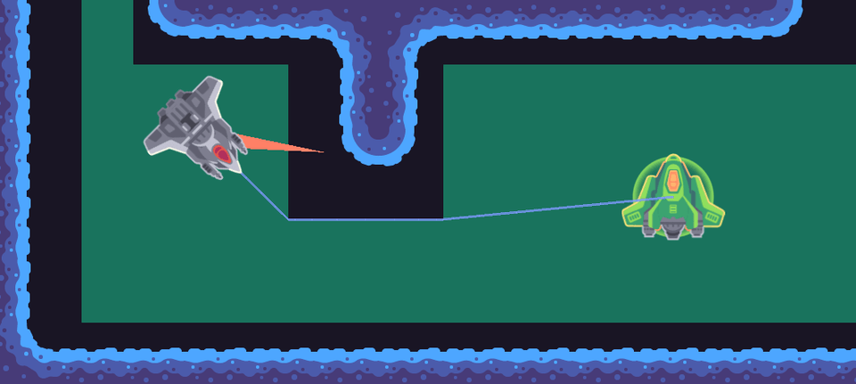

We use a tilemap to make walls and set a `NavigationPolygon` to fill the space around the cells.

**Note:** You can use a `TileMap` in place of the `NavigationPolygonInstance` if you have set up its navigation option for each tile.

Bear in mind that your ship can travel to have its center at any point in the `NavigationPolygon`. To keep your ship from clipping through walls, leave plenty of space between the polygon and the walls.

Our enemies use these nodes:

1. `Path2D` (*SeekingEnemy*)
2. `PathFollow2D`
3. `KinematicBody2D` (*Enemy*)
4. `Sprite`
5. `Timer`
6. `Line2D` to draw their path
7. `Tween`

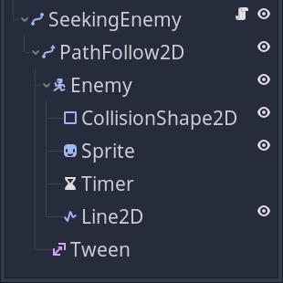

The `Timer` is great in this situation. It lets us regularly update our path without being as wasteful as updating the path every frame.

```
const SPEED := 400.0

export var _navigation2d_path: NodePath
export var _player_path: NodePath

onready var _navigator: Navigation2D = get_node(_navigation2d_path)
onready var _player: Player = get_node(_player_path)

onready var _ship: KinematicBody2D = $PathFollow2D/Enemy
onready var _line: Line2D = $PathFollow2D/Enemy/Line2D
onready var _path_follow: PathFollow2D = $PathFollow2D
onready var _timer: Timer = $PathFollow2D/Enemy/Timer
onready var _tween: Tween = $PathFollow2D/Tween


func _ready() -> void:
    _timer.connect("timeout", self, "_on_Timer_timeout")
```

Our ship needs a reference to the `Navigation2D` to generate our paths. We can set our `Timer` to timeout every `0.1` seconds, then set the path for the ship to follow in this callback.

Start by clearing the curve in our `Path2D`, then add each point in our generated path one at a time to the curve.

We can use our `Tween` to move along the new path. We need to calculate how long it should take to traverse using the baked length of the curve and a set speed for the ship.

**Note:** If you want to add acceleration or deceleration, you can either interpolate a method with your `Tween` to change the speed contextually, or make the ship move towards the `PathFollow2D` as a target.

```
func _on_Timer_timeout() -> void:
    curve.clear_points()
    for point in _navigator.get_simple_path(_path_follow.position, _player.position):
        curve.add_point(point)
    _tween.interpolate_property(
        _path_follow, "unit_offset", 0.0, 1.0, curve.get_baked_length() / SPEED
    )
    _tween.start()
```

### Grid-based navigation

Many games have pathfinding with restricted areas units can stand on; especially turn-based tactics games like *XCOM*.

If you want to restrict your movement to start and end on a grid, but you don’t mind if the movement isn’t locked to the grid, then `Navigation2D` is an excellent option.

[figure not shown]

*Game: XCOM: Enemy Unknown (2012)*

The principle of using a `Navigation2D` for grid-based movement is the same as with enemy AI in the previous example, but you need some extra steps to ensure the start and end positions are the nearest valid grid space.

Thankfully, Godot has a great built-in function when wrapping numbers like this: `stepify()`.

You pass in a base number and the step value, which is the size of your grid. Then your base number becomes the closest multiple of that step.

Alternatively, you can use the `Vector2` `snapped()` function to achieve the same result by passing in a *Vector* with x and y values equal to your desired step.

```
## Rounds each component of the vector to the `step` value.
func stepify_vector(vector_in: Vector2, step: float) -> Vector2:
    return Vector2(stepify(vector_in.x, step), stepify(vector_in.y, step))
```

We use a sprite to indicate where the player is hovering and store the target location when the player clicks. To do this, we pass our mouse position into the `stepify()` function whenever there is a mouse `Input` event.

Once we call `stepify()` on the local mouse position, we pass that location to the `Navigation2D` to find the nearest valid position using the `get_closest_point()` function if the user was hovering outside the `NavigationPolygonInstance` boundaries.

Now we have stored the player’s position to move to, we need to call a function to move the ship when the player clicks.

In this function, we use `Navigation2D` to get a path from the player’s current `PathFollow` position to the target. This uses paths to move the ship like the “Enemy chasing the player” example above.

```
func move_ship_to_click(target_position: Vector2) -> void:
    # We use Path2D and PathFollow2D nodes to make the ship move along the navigation path.
    # This makes it easy to do navigation; all we have to do is feed the navigation path
    # to the Path2D node's `curve`.
    _path.curve.clear_points()
    for point in _navigator.get_simple_path(_path_follow.position, target_position):
        _path.curve.add_point(point)
    # Animating the offset or unit_offset property of PathFollow2D makes the ship move along
    # the parent Path2D node.
    _tween.interpolate_property(
        _path_follow, "unit_offset", 0.0, 1.0, _path.curve.get_baked_length() / SPEED
    )
    _tween.start()
```

### Making areas inaccessible with doors

It’s rare to have explorable worlds that don’t have some form of gate or door. In games like *Resident Evil*, different areas become available as you progress through the game, but certain enemies need to be able to follow you through doors once they’re unlocked.

One way to get enemies to respond to unlocked doors is to use a `Navigation2D` with multiple `NavigationPolygonInstance` children. You can switch between them using the *Enabled* property.

This method works well in simpler situtations because the number of `NavigationPolygonInstance` nodes increases exponentially with every locked door. With this approach, you also need code to handle the *Enabled* property for each `NavigationPolygonInstance`.

For our example we made two doors and one switch. The switch opens one door and closes the other. As a result, we only have two states to swap between, so we need two `NavigationPolygonInstance` nodes.

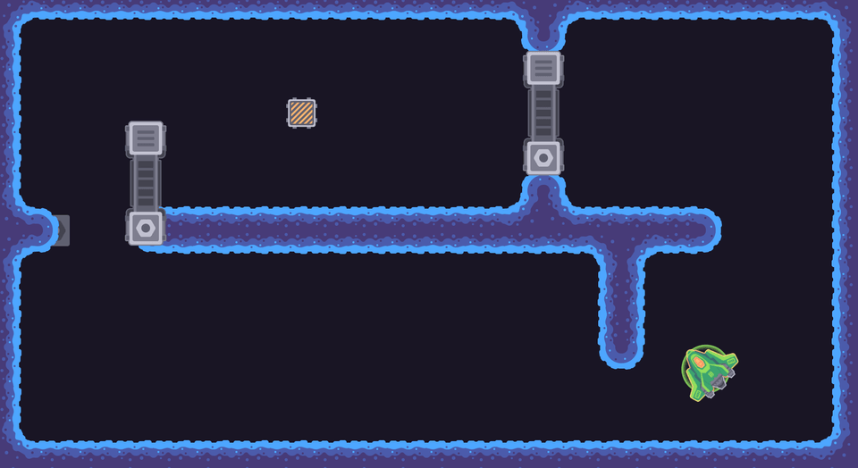

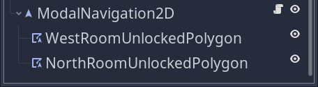

You can read more about the door and pressure plate mechanisms in the Area2D guide.

Here we use a `Dictionary`, so the script can enable its matching `NavigationPolygonInstance` when one door opens and disable the rest.

```
export var west_door_path: NodePath
export var north_door_path: NodePath

onready var _west_door: StaticBody2D = get_node(west_door_path)
onready var _north_door: StaticBody2D = get_node(north_door_path)
onready var door_map := {
    _west_door: $WestRoomUnlockedPolygon, _north_door: $NorthRoomUnlockedPolygon
}


func _ready() -> void:
    _west_door.activate()
    door_map[_west_door].enabled = true


func activate() -> void:
    for door in door_map:
        door.activate()
        door_map[door].enabled = door.activated
```

### Reacting to moving hazards

If you want your AI to react to hazards, danger, and traps in real-time, it’s possible to update the `NavigationPolygon` resource to reflect the hazards.

We have a scene where a ship patrols around a random path but avoids the black hole and keeps a safe distance at all times.

We achieve this by removing the region where the black hole is from the `NavigationPolygon` entirely.

[figure not shown]

The process of removing a polygon from a `NavigationPolygon` requires a few steps.

Our black hole is an `Area2D` with a collision polygon. We need a `CollisionPolygon2D` rather than a `CollisionShape2D` to use the outline of the polygon to remove it from the `NavigationPolygon`.

This `CollisionPolygon2D` is in a group called hazard so that the `Navigation2D` can easily get every shape to avoid whenever it tries to update.

Whenever this black hole moves, we emit a signal to update the `NavigationPolygon`.

```
    if Input.is_action_pressed("click") and event is InputEventMouseMotion:
        position += event.relative
        emit_signal("update_position")
```

We store the original polygon in a variable called `base_polygon`. This way, when we try to update the position of our black hole, we can get a copy of the original polygon and update that so our changes aren’t permanent.

As the polygon is a resource, we need to use the `duplicate()` method. Otherwise, every time we alter the polygon, it would change the original by reference.

We can now loop over all our `CollisionPolygon2D` hazards and get their polygon data. We need to combine this polygon data with the transform information for the polygon so its scale and rotation are correct. You can do this with the `xform()` function.

The engine removes any areas where polygons overlap from the shape, so we should end up with a large area with a space hollowed out where the black hole’s collision shape is.

The last step is to update our `NavigationPolygon` to use this newly created polygon, and we’re done!

```
signal navigation_updated

onready var _polygon_instance: NavigationPolygonInstance = $NavigationPolygonInstance
onready var _base_polygon := _polygon_instance.get_navigation_polygon()


func setup_hazards() -> void:
    var hazard_list := get_tree().get_nodes_in_group("Hazard")
    var polygon := _base_polygon.duplicate()
    for child in hazard_list:
        assert(child is CollisionPolygon2D, "invalid Hazard type")
        var outline := []
        for point in child.get_polygon():
            outline.append(child.get_global_transform_with_canvas().xform(point))
        polygon.add_outline(outline)
        polygon.make_polygons_from_outlines()
    _polygon_instance.set_navigation_polygon(polygon)
    emit_signal("navigation_updated")
```

This process can be complex if the collision shape goes outside your original boundaries because the shape adds to the `NavigationPolygon` instead of subtracting from it.

This process excels in stable environments to automatically remove static areas with hazards from a large `NavigationPolygon`. In cases like that, you can also save the polygon to a resource at run time, so you only need to generate the polygon when your scene changes rather than every time it runs.

## Your questions

### When should I use AStar?

You can get more robust results and control using the `AStar` algorithm but with more manual work. If you’re struggling with the unpredictable and imprecise nature of `Navigation2D` in Godot 3.x, it’s worth considering implementing the pathfinding yourself using `AStar`. You can read the [Godot Docs on AStar here.](https://docs.godotengine.org/en/stable/classes/class_astar.html)

### How can I see my Navigation shapes?

Godot has a handy option in the debug dropdown. The *Visible Navigation* checkmark makes all *NavigationPolygons* visible in-game when enabled and draws any paths the `Navigation2D` generates.

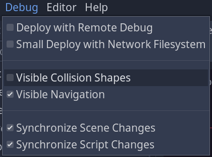

### Can I create my NavigationPolygon in code?

You can, but you still need a `NavigationPolygonInstance` to attach it to. To create a `NavigationPolygon` from code, you need to call `add_outline()` and `make_polygons_from_outline()`. Whenever you add an outline, if it overlaps another outline, that area remains blank. Otherwise, the space becomes a solid polygon.